# Assignment_8

Author

Wiktoria Brandys

## Assignment

In previous assignment I found one plot from Healthy Reefs website as an example of “bad plotting”

Those are ideas that I though that can improve this plot - both visually but also substantively:

- First of all, I would ensure that the bar heights accurately reflect the percentage values. For example 60% bar should be exactly 1.5 times taller than 40% bar.
- I would also add a title or subtitle that explains what the percentages refer to and include a properly labelled Y-axis for better interpretation.
- Additionally, I would also change the color palette. While the current colors do differentiate between categories, I would prefer higher contrast shades to make the distinctions clearer
- I would change the X-axis legend, describing bars by keywords for the issue.

## Code

Since, I did not have access to real data, I simulated it using the rnorm() function to generates random numbers from a normal distribution and set.seed() to ensure reproducibility. Than I created a table to sort the data and to be able to do a plot later.

```r
set.seed(16)

group <- c('7a', '7b', '7c')
labels <-c("7a. Reef Resilience Identification", "7b. Engagement in International Treaties", "7c. Carbon Sequetration Inceives")
percentage <- round(c(rnorm(1, mean=40, sd=2),
                      rnorm(1, mean=80, sd=2),
                      rnorm(1, mean=70, sd=2)))

table <- data.frame(Category=group, Percentage=percentage, Labels=labels)
show(table)
```

```
  Category Percentage                                   Labels
1       7a         41       7a. Reef Resilience Identification
2       7b         80 7b. Engagement in International Treaties
3       7c         72         7c. Carbon Sequetration Inceives
```

To be able to do the following work I needed to load and install some libraries:

```r
library(ggplot2)
library(scales)
library(viridis)
```

This code creates a bar chart depending on the data that I simulated.  
- The Category variable is used on the x-axis and Percentage determines the height of each bar (y-axis). - Each bar is filled based on the Labels variable, which provides descriptive names for each issue.  
- The `geom_text()` function adds percentage labels above each bar. - Moreover, the y-axis is scaled from 0 to 100 to show real scale of the percentage.  
- A `theme_minimal()` is applied for a clean style.  
- There is also a char’s title which is placed in the middle and I changed the legend title for clarity.  
- Additionally, the viridis color palette is used to apply more contrasting colors while maintaining a blue theme, which is appropriate for the marine theme.

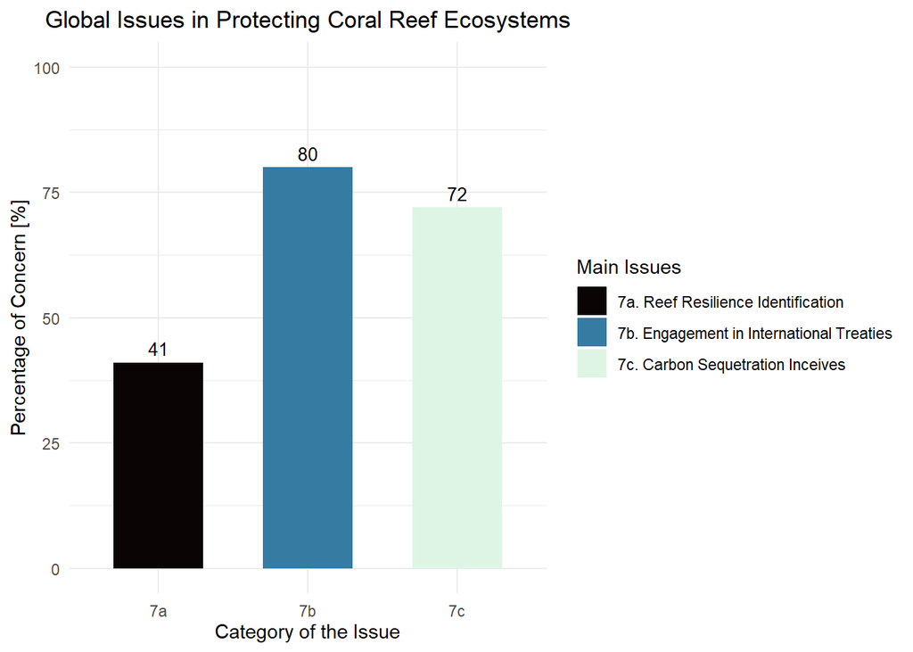

```r
plot <- ggplot(data=table, aes(x=Category, y=Percentage, fill=Labels))+
  geom_bar(stat="identity", width = 0.6, )+
  geom_text(aes(label = Percentage), vjust = -0.5, size=3.5)+
  ylim(0,100)+
  labs(title="Global Issues in Protecting Coral Reef Ecosystems",
       x="Category of the Issue",
       y="Percentage of Concern [%]",
       fill= "Main Issues")+
  theme_minimal() +
  theme(plot.title = element_text(hjust = 0.5),
        axis.text.x = element_text(angle=0, vjust = 0.5, hjust=0.5))+
  scale_fill_viridis(discrete="TRUE", option = "mako")

plot
```